# Sistema de recomendación de libros

## Parte I: Análisis exploratorio

Iniciamos cargando las librerias y leyendo los archivos de datos.

```r
library(recommenderlab) # Incluye los algoritmos UBCF, IBCF, FunkSVD
library(data.table)
library(dplyr) # Permite trabajar con objetos data frame de manera rápida.Enfocada a textos.

library(tidyr) # Manipular datos
library(ggplot2) # Graficar
library(stringr) # Operaciones de texto
library(DT) # Interfaz para visualizar DataTables
library(knitr) # Generar reportes
library(grid) # Graficas
library(gridExtra) # Graficas
library(corrplot) # Visualizar matrices de correlación
library(qgraph) # Graficas
library(methods) # Metodos y clases para objetos
library(Matrix) # Operaciones sobre matrices


books <- fread('./input/books.csv')
ratings <- fread('./input/ratings.csv')
book_tags <- fread('./input/book_tags.csv')
tags <- fread('./input/tags.csv')
```

Ahora necesitamos revisar los datos que nos han proporcionado. Estos consisten de los archivos: `ratings.csv`, `books.csv`, `book_tags.csv`, `tags.csv`.

#### Ratings.csv

|  | book_id | user_id | rating |
| --- | --- | --- | --- |
| 1 | 1 | 314 | 5 |
| 2 | 1 | 439 | 3 |
| 3 | 1 | 588 | 5 |
| 4 | 1 | 1169 | 4 |
| 5 | 1 | 1185 | 4 |
| 6 | 1 | 2077 | 4 |
| 7 | 1 | 2487 | 4 |
| 8 | 1 | 2900 | 5 |
| 9 | 1 | 3662 | 4 |
| 10 | 1 | 3922 | 5 |

```
## Rows: 79,701
## Columns: 3
## $ book_id <int> 1, 1, 1, 1, 1, 1, 1, 1, 1, 1, 1, 1, 1, 1, 1, 1, 1, 1, 1, 1, 1,~
## $ user_id <int> 314, 439, 588, 1169, 1185, 2077, 2487, 2900, 3662, 3922, 5379,~
## $ rating  <int> 5, 3, 5, 4, 4, 4, 4, 5, 4, 5, 5, 3, 5, 5, 3, 1, 4, 5, 4, 4, 5,~
```

#### Books.csv

|  | id | book_id | best_book_id | work_id | books_count | isbn | isbn13 | authors | original_publication_year | original_title | title | language_code | average_rating | ratings_count | work_ratings_count | work_text_reviews_count | ratings_1 | ratings_2 | ratings_3 | ratings_4 | ratings_5 | image_url | small_image_url |
| --- | --- | --- | --- | --- | --- | --- | --- | --- | --- | --- | --- | --- | --- | --- | --- | --- | --- | --- | --- | --- | --- | --- | --- |
| 1 | 1 | 2767052 | 2767052 | 2792775 | 272 | 439023483 | 9780439023480 | Suzanne Collins | 2008 | The Hunger Games | The Hunger Games (The Hunger Games, #1) | eng | 4.34 | 4780653 | 4942365 | 155254 | 66715 | 127936 | 560092 | 1481305 | 2706317 | https://images.gr-assets.com/books/1447303603m/2767052.jpg | https://images.gr-assets.com/books/1447303603s/2767052.jpg |
| 2 | 2 | 3 | 3 | 4640799 | 491 | 439554934 | 9780439554930 | J.K. Rowling, Mary GrandPrÃ© | 1997 | Harry Potter and the Philosopher's Stone | Harry Potter and the Sorcerer's Stone (Harry Potter, #1) | eng | 4.44 | 4602479 | 4800065 | 75867 | 75504 | 101676 | 455024 | 1156318 | 3011543 | https://images.gr-assets.com/books/1474154022m/3.jpg | https://images.gr-assets.com/books/1474154022s/3.jpg |
| 3 | 3 | 41865 | 41865 | 3212258 | 226 | 316015849 | 9780316015840 | Stephenie Meyer | 2005 | Twilight | Twilight (Twilight, #1) | en-US | 3.57 | 3866839 | 3916824 | 95009 | 456191 | 436802 | 793319 | 875073 | 1355439 | https://images.gr-assets.com/books/1361039443m/41865.jpg | https://images.gr-assets.com/books/1361039443s/41865.jpg |
| 4 | 4 | 2657 | 2657 | 3275794 | 487 | 61120081 | 9780061120080 | Harper Lee | 1960 | To Kill a Mockingbird | To Kill a Mockingbird | eng | 4.25 | 3198671 | 3340896 | 72586 | 60427 | 117415 | 446835 | 1001952 | 1714267 | https://images.gr-assets.com/books/1361975680m/2657.jpg | https://images.gr-assets.com/books/1361975680s/2657.jpg |
| 5 | 5 | 4671 | 4671 | 245494 | 1356 | 743273567 | 9780743273560 | F. Scott Fitzgerald | 1925 | The Great Gatsby | The Great Gatsby | eng | 3.89 | 2683664 | 2773745 | 51992 | 86236 | 197621 | 606158 | 936012 | 947718 | https://images.gr-assets.com/books/1490528560m/4671.jpg | https://images.gr-assets.com/books/1490528560s/4671.jpg |

```
## Rows: 10,000
## Columns: 23
## $ id                        <int> 1, 2, 3, 4, 5, 6, 7, 8, 9, 10, 11, 12, 13, 1~
## $ book_id                   <int> 2767052, 3, 41865, 2657, 4671, 11870085, 590~
## $ best_book_id              <int> 2767052, 3, 41865, 2657, 4671, 11870085, 590~
## $ work_id                   <int> 2792775, 4640799, 3212258, 3275794, 245494, ~
## $ books_count               <int> 272, 491, 226, 487, 1356, 226, 969, 360, 311~
## $ isbn                      <chr> "439023483", "439554934", "316015849", "6112~
## $ isbn13                    <int64> 9780439023480, 9780439554930, 978031601584~
## $ authors                   <chr> "Suzanne Collins", "J.K. Rowling, Mary Grand~
## $ original_publication_year <int> 2008, 1997, 2005, 1960, 1925, 2012, 1937, 19~
## $ original_title            <chr> "The Hunger Games", "Harry Potter and the Ph~
## $ title                     <chr> "The Hunger Games (The Hunger Games, #1)", "~
## $ language_code             <chr> "eng", "eng", "en-US", "eng", "eng", "eng", ~
## $ average_rating            <dbl> 4.34, 4.44, 3.57, 4.25, 3.89, 4.26, 4.25, 3.~
## $ ratings_count             <int> 4780653, 4602479, 3866839, 3198671, 2683664,~
## $ work_ratings_count        <int> 4942365, 4800065, 3916824, 3340896, 2773745,~
## $ work_text_reviews_count   <int> 155254, 75867, 95009, 72586, 51992, 140739, ~
## $ ratings_1                 <int> 66715, 75504, 456191, 60427, 86236, 47994, 4~
## $ ratings_2                 <int> 127936, 101676, 436802, 117415, 197621, 9272~
## $ ratings_3                 <int> 560092, 455024, 793319, 446835, 606158, 3275~
## $ ratings_4                 <int> 1481305, 1156318, 875073, 1001952, 936012, 6~
## $ ratings_5                 <int> 2706317, 3011543, 1355439, 1714267, 947718, ~
## $ image_url                 <chr> "https://images.gr-assets.com/books/14473036~
## $ small_image_url           <chr> "https://images.gr-assets.com/books/14473036~
```

#### Book_tags.csv

|  | goodreads_book_id | tag_id | count |
| --- | --- | --- | --- |
| 1 | 1 | 30574 | 167697 |
| 2 | 1 | 11305 | 37174 |
| 3 | 1 | 11557 | 34173 |
| 4 | 1 | 8717 | 12986 |
| 5 | 1 | 33114 | 12716 |
| 6 | 1 | 11743 | 9954 |
| 7 | 1 | 14017 | 7169 |
| 8 | 1 | 5207 | 6221 |
| 9 | 1 | 22743 | 4974 |
| 10 | 1 | 32989 | 4364 |

```
## Rows: 999,912
## Columns: 3
## $ goodreads_book_id <int> 1, 1, 1, 1, 1, 1, 1, 1, 1, 1, 1, 1, 1, 1, 1, 1, 1, 1~
## $ tag_id            <int> 30574, 11305, 11557, 8717, 33114, 11743, 14017, 5207~
## $ count             <int> 167697, 37174, 34173, 12986, 12716, 9954, 7169, 6221~
```

#### Tags.csv

|  | tag_id | tag_name |
| --- | --- | --- |
| 1 | 21614 | no |
| 2 | 2622 | ann-rice |
| 3 | 23748 | plays-broadway |
| 4 | 1884 | air-disasters |
| 5 | 6025 | buy-kindle-version |
| 6 | 26352 | runot |
| 7 | 26693 | scandinavian-nordic |
| 8 | 24052 | post-apocalyptic-dystopia |
| 9 | 31941 | virtual |
| 10 | 26526 | samantha-young |

```
## Rows: 34,252
## Columns: 2
## $ tag_id   <int> 0, 1, 2, 3, 4, 5, 6, 7, 8, 9, 10, 11, 12, 13, 14, 15, 16, 17,~
## $ tag_name <chr> "-", "--1-", "--10-", "--12-", "--122-", "--166-", "--17-", "~
```

### Limpiando el conjunto de datos

Como con cualquier conjunto de datos de la vida real, primero necesitamos hacer una pequeña limpieza a los datos. Cuando realizamos la exploración notamos que algunas combinaciones de usuarios y libros tienen multiples puntuajes cuando en teoría solamente debe existir uno por usuario.

Removemos los registros duplicados.

```r
ratings[, N := .N, .(user_id, book_id)]
## corresponding dplyr code
# ratings %>% group_by(user_id, book_id) %>% mutate(n=n())
cat('Number of duplicate ratings: ', nrow(ratings[N > 1]))
```

```
## Number of duplicate ratings:  338
```

```r
ratings <- ratings[N == 1]
cat('\nNumber of duplicate ratings: ', nrow(ratings[N > 1]))
```

```
##
## Number of duplicate ratings:  0
```

```r
summary(ratings)
```

```
##     book_id        user_id          rating            N
##  Min.   :   1   Min.   :    2   Min.   :1.000   Min.   :1
##  1st Qu.:2657   1st Qu.:12638   1st Qu.:3.000   1st Qu.:1
##  Median :5068   Median :25182   Median :4.000   Median :1
##  Mean   :4908   Mean   :25749   Mean   :3.861   Mean   :1
##  3rd Qu.:7073   3rd Qu.:38615   3rd Qu.:5.000   3rd Qu.:1
##  Max.   :9998   Max.   :53424   Max.   :5.000   Max.   :1
```

y removemos aquellos usuarios que han calificado menos de 3 libros

```r
ratings[, N := .N, .(user_id)]
## corresponding dplyr code
# ratings %>% group_by(user_id) %>% mutate(n = n())
cat('Número de usuarios que calificaron menos de 3 libros: ', uniqueN(ratings[N <= 2, user_id]))
```

```
## Número de usuarios que calificaron menos de 3 libros:  18842
```

```r
ratings <- ratings[N > 2]
```

```r
summary(ratings)
```

```
##     book_id        user_id          rating            N
##  Min.   :   1   Min.   :    7   Min.   :1.000   Min.   : 3.000
##  1st Qu.:1715   1st Qu.:12399   1st Qu.:3.000   1st Qu.: 4.000
##  Median :4135   Median :24613   Median :4.000   Median : 6.000
##  Mean   :4145   Mean   :25427   Mean   :3.858   Mean   : 7.652
##  3rd Qu.:6150   3rd Qu.:38124   3rd Qu.:5.000   3rd Qu.: 9.000
##  Max.   :9998   Max.   :53403   Max.   :5.000   Max.   :32.000
```

### Empezamos la exploración de los datos

**¿Cuál es la distribución de los datos?**

Podemos ver que ya la mayoría de las calificaciones tienden a ser positivas. La mayoría de las calificaciones están en el rango de 3-5, mientras que pocas calificaciones están en el rango de 1-2.

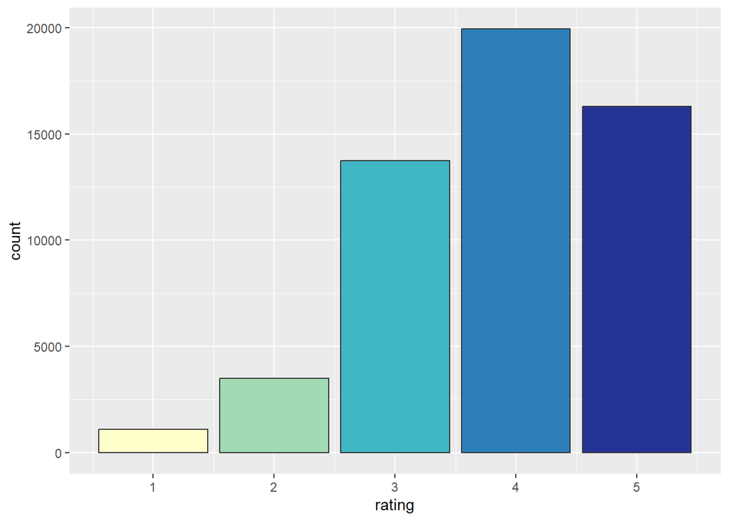

```r
ratings %>%
  ggplot(aes(x = rating,
             fill = factor(rating))) +
  geom_bar(color = "grey20") +
  scale_fill_brewer(palette = "YlGnBu") +
  guides(fill = FALSE)
```

### Número de calificaciones por usuario

Podemos observar que hay algunos usuarios que han dado muchas calificaciones. Esto es interesante porque podemos examinar como se comportan las calificaciones de los usuarios más activos de los menos activos.

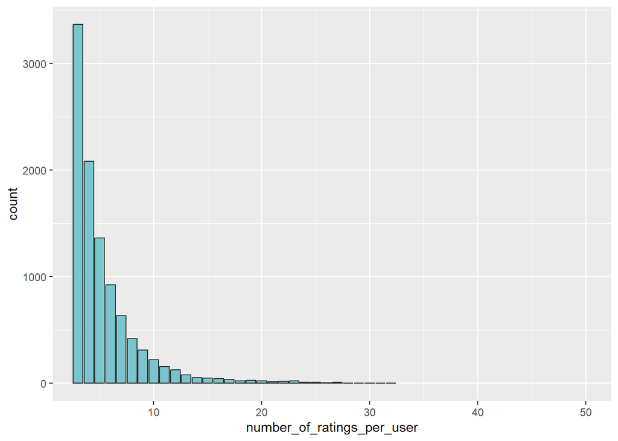

```r
ratings %>%
  group_by(user_id) %>%
  summarize(number_of_ratings_per_user = n()) %>%
  ggplot(aes(number_of_ratings_per_user)) +
  geom_bar(fill = "cadetblue3", color = "grey20") +
  coord_cartesian(c(3, 50))
```

**Distribucion media de calificaciones de usuarios**

Los usuarios tienen diferentes tendencias al calificar libros. Algunos pueden dar 5 estrellas a libros mediocres, mientras que otros no dan calificacion de 5 al menos que sea un libro perfecto para ellos. Estas tendencias se pueden observar en las siguientes figuras. En el lado derecho hay un gran número de usuarios con una calificación media de 5, indicando que a ellos realmente les gustaron todos los libros o que solamente calificaron libros que les gustaron. También podemos observar que casi no hay calificaciones bajas. Estas tendencias serán importantes para el filtro colaborativo que veremos despues.

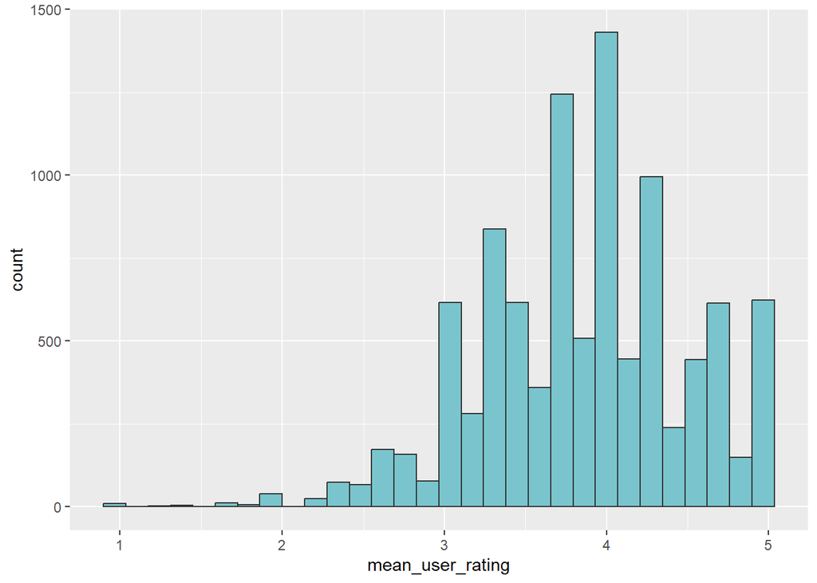

```r
ratings %>%
  group_by(user_id) %>%
  summarize(mean_user_rating = mean(rating)) %>%
  ggplot(aes(mean_user_rating)) +
  geom_histogram(fill = "cadetblue3", color = "grey20")
```

```r
ratings %>%
  group_by(book_id) %>%
  summarize(number_of_ratings_per_book = sum(n()))
```

| book_id | number_of_ratings_per_book |
| --- | --- |
| 1 | 100 |
| 2 | 100 |
| 3 | 100 |
| 5 | 100 |
| 6 | 100 |
| 8 | 100 |
| 10 | 100 |
| 11 | 100 |
| 13 | 100 |
| 21 | 100 |

[output cut: 802 more lines]

**Número de calificaciones por libro.**

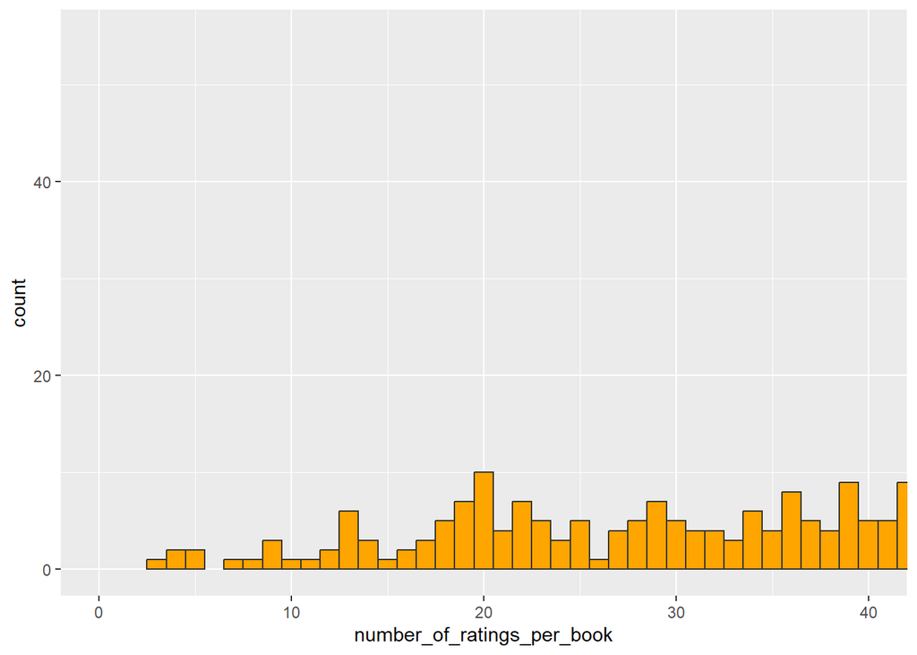

```r
ratings %>%
  group_by(book_id) %>%
  summarize(number_of_ratings_per_book = n()) %>%
  ggplot(aes(number_of_ratings_per_book)) +
  geom_bar(fill = "orange", color = "grey20", width = 1) + coord_cartesian(c(0,40))
```

**Distribución de calificación media de los libros.**

La distribución media no muestra ninguna peculiaridad.

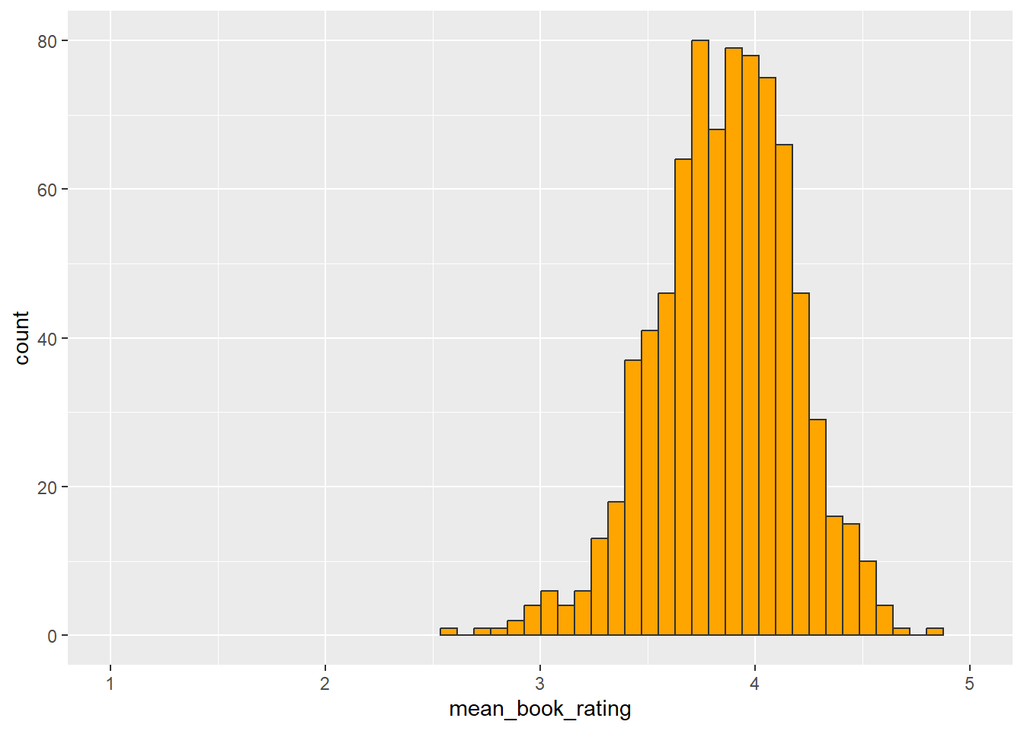

```r
ratings %>%
  group_by(book_id) %>%
  summarize(mean_book_rating = mean(rating)) %>%
  ggplot(aes(mean_book_rating)) +
  geom_histogram(fill = "orange", color = "grey20") + coord_cartesian(c(1,5))
```

**Distribución de generos.**

Extraer el genero del libro no es una tarea trivial ya que los usuarios asignan las etiquetas a los libros, el cual podría o no coinicidir con el genero establecido por GoodReads. Una forma de hacerlo es esocger las etiqutes que coinicidan con las indicadas por GoodReads.

Se puede observar que la mayoría de los libros son de Fantasía, romance o misterio, mientras que no hay muchos de cocina.

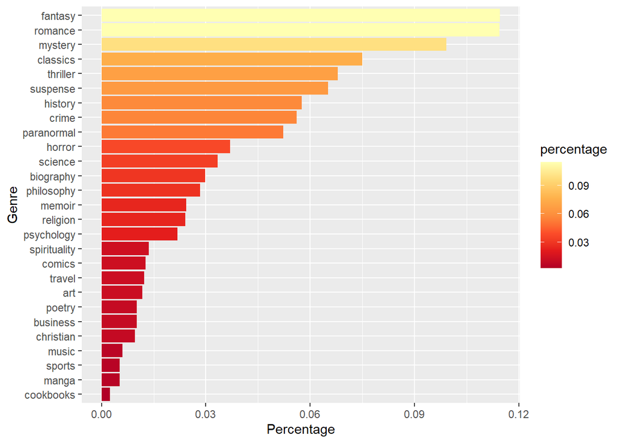

```r
genres <- str_to_lower(c("Art", "Biography", "Business", "Chick Lit", "Children's", "Christian", "Classics", "Comics", "Contemporary", "Cookbooks", "Crime", "Ebooks", "Fantasy", "Fiction", "Gay and Lesbian", "Graphic Novels", "Historical Fiction", "History", "Horror", "Humor and Comedy", "Manga", "Memoir", "Music", "Mystery", "Nonfiction", "Paranormal", "Philosophy", "Poetry", "Psychology", "Religion", "Romance", "Science", "Science Fiction", "Self Help", "Suspense", "Spirituality", "Sports", "Thriller", "Travel", "Young Adult"))

exclude_genres <- c("fiction", "nonfiction", "ebooks", "contemporary")
genres <- setdiff(genres, exclude_genres)

available_genres <- genres[str_to_lower(genres) %in% tags$tag_name]
available_tags <- tags$tag_id[match(available_genres, tags$tag_name)]

tmp <- book_tags %>%
  filter(tag_id %in% available_tags) %>%
  group_by(tag_id) %>%
  summarize(n = n()) %>%
  ungroup() %>%
  mutate(sumN = sum(n), percentage = n / sumN) %>%
  arrange(-percentage) %>%
  left_join(tags, by = "tag_id")

tmp %>%
  ggplot(aes(reorder(tag_name, percentage),
             percentage, fill = percentage)) +
  geom_bar(stat = "identity") +
  coord_flip() +
  scale_fill_distiller(palette = 'YlOrRd') +
  labs(y = 'Percentage', x = 'Genre')
```

**Top 10 de libros mejor calificados.**

Se muestra que a los usuarios les suele gustar:

- Calvin and Hobbes,
- Algunas colecciones de libros.

```r
books %>%
  mutate(image = paste0('<img src="', small_image_url, '"></img>')) %>%
  arrange(-average_rating) %>%
  top_n(10,wt = average_rating) %>%
  select(image, title, ratings_count, average_rating) %>%
  datatable(class = "nowrap hover row-border", escape = FALSE, options = list(dom = 't',scrollX = TRUE, autoWidth = TRUE))
```

|  | image | title | ratings_count | average_rating |
| --- | --- | --- | --- | --- |
| 1 |  | The Complete Calvin and Hobbes | 28900 | 4.82 |
| 2 |  | Words of Radiance (The Stormlight Archive, #2) | 73572 | 4.77 |
| 3 |  | Harry Potter Boxed Set, Books 1-5 (Harry Potter, #1-5) | 33220 | 4.77 |
| 4 |  | ESV Study Bible | 8953 | 4.76 |
| 5 |  | Mark of the Lion Trilogy | 9081 | 4.76 |
| 6 |  | It's a Magical World: A Calvin and Hobbes Collection | 22351 | 4.75 |
| 7 |  | Harry Potter Boxset (Harry Potter, #1-7) | 190050 | 4.74 |
| 8 |  | There's Treasure Everywhere: A Calvin and Hobbes Collection | 16766 | 4.74 |
| 9 |  | Harry Potter Collection (Harry Potter, #1-6) | 24618 | 4.73 |
| 10 |  | The Authoritative Calvin and Hobbes: A Calvin and Hobbes Treasury | 16087 | 4.73 |

[output cut: 1 more lines]

```r
## TE RECOMENDAMOS COPIES EL CÓDIGO Y LO PEGUES EN LA CONSOLA PARA QUE VISUALICES LA LISTA COMPLETA.
```

**Top 10 de libros populares.**

Viendo los libros que han recibido más calificaciones nos podemos dar una idea de su popularidad.

```r
books %>%
  mutate(image = paste0('<img src="', small_image_url, '"></img>')) %>%
  arrange(-ratings_count) %>%
  top_n(10,wt = ratings_count) %>%
  select(image, title, ratings_count, average_rating) %>%
  datatable(class = "nowrap hover row-border",
            escape = FALSE,
            options = list(dom = 't', scrollX = TRUE, autoWidth = TRUE))
```

|  | image | title | ratings_count | average_rating |
| --- | --- | --- | --- | --- |
| 1 |  | The Hunger Games (The Hunger Games, #1) | 4780653 | 4.34 |
| 2 |  | Harry Potter and the Sorcerer's Stone (Harry Potter, #1) | 4602479 | 4.44 |
| 3 |  | Twilight (Twilight, #1) | 3866839 | 3.57 |
| 4 |  | To Kill a Mockingbird | 3198671 | 4.25 |
| 5 |  | The Great Gatsby | 2683664 | 3.89 |
| 6 |  | The Fault in Our Stars | 2346404 | 4.26 |
| 7 |  | The Hobbit | 2071616 | 4.25 |
| 8 |  | The Catcher in the Rye | 2044241 | 3.79 |
| 9 |  | Pride and Prejudice | 2035490 | 4.24 |
| 10 |  | Angels & Demons (Robert Langdon, #1) | 2001311 | 3.85 |

**Idiomas de los libros.**

Como vimos al inicio el dataset `books.csv` contiene información sobre el idioma en que está escrito el libro.

Podemos explorar que tantos libros existe en otros idiomas.

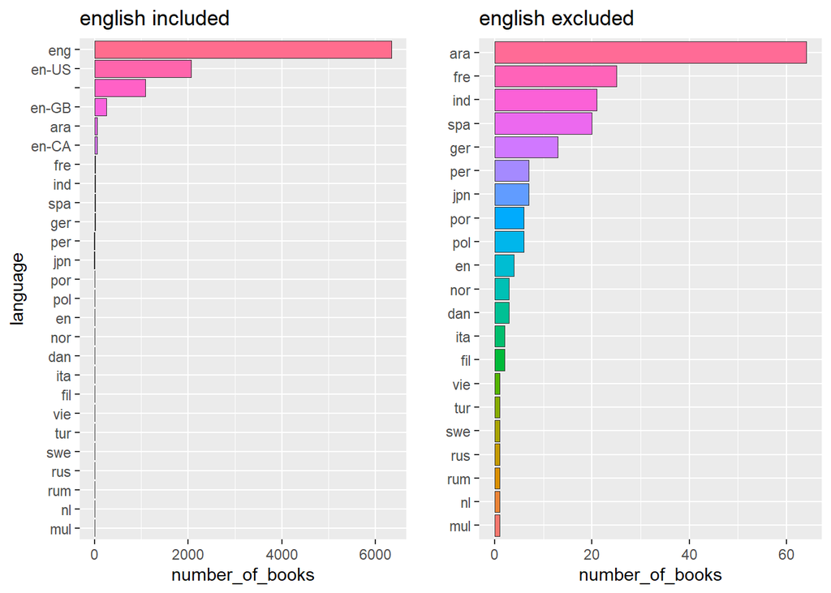

```r
p1 <- books %>%
  mutate(language = factor(language_code)) %>%
  group_by(language) %>%
  summarize(number_of_books = n()) %>%
  arrange(-number_of_books) %>%
  ggplot(aes(reorder(language,
                     number_of_books),
             number_of_books,
             fill = reorder(language, number_of_books))) +
  geom_bar(stat = "identity", color = "grey20", size = 0.35) +
  coord_flip() +
  labs(x = "language", title = "english included") +
  guides(fill = FALSE)

p2 <- books %>%
  mutate(language = factor(language_code)) %>%
  filter(!language %in% c("en-US", "en-GB", "eng", "en-CA", "")) %>%
  group_by(language) %>%
  summarize(number_of_books = n()) %>%
  arrange(-number_of_books) %>%
  ggplot(aes(reorder(language, number_of_books), number_of_books, fill = reorder(language, number_of_books))) +
  geom_bar(stat = "identity", color = "grey20", size = 0.35) + coord_flip() +
  labs(x = "", title = "english excluded") + guides(fill = FALSE)

grid.arrange(p1,p2, ncol=2)
```

**¿Qué influencia la calificación de un libro?.**

A continuación podemos ver si encontramos alguna asociación de características con la calificación de un libro.

Para una vista rápida, primero vamos a generar una gráfica de la matriz de correlación entre el promedio de califación `average_rating` y algunas variables.

En resumen, solamente podemos encontrar una pequeña correlación entre las características y la calificación promedio. Lo cual indica que no hay una relación fuerte entre la calificación que recibe un libr y sus meta-variables. Lo cual indica que la calificación depende fuertemente en otras características.

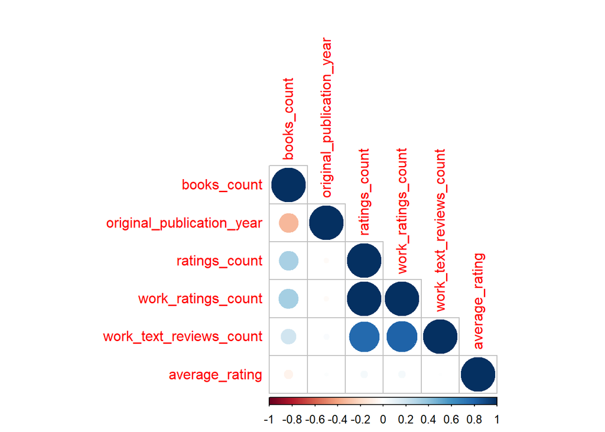

```r
tmp <- books %>%
  select(one_of(c("books_count","original_publication_year","ratings_count", "work_ratings_count", "work_text_reviews_count", "average_rating"))) %>%
  as.matrix()

corrplot(cor(tmp, use = 'pairwise.complete.obs'), type = "lower")
```

**¿Es mejor la secuela que la original?.**

Podemos ver que dentro de una serie, las secuelas son ligeramente mejor que el original.

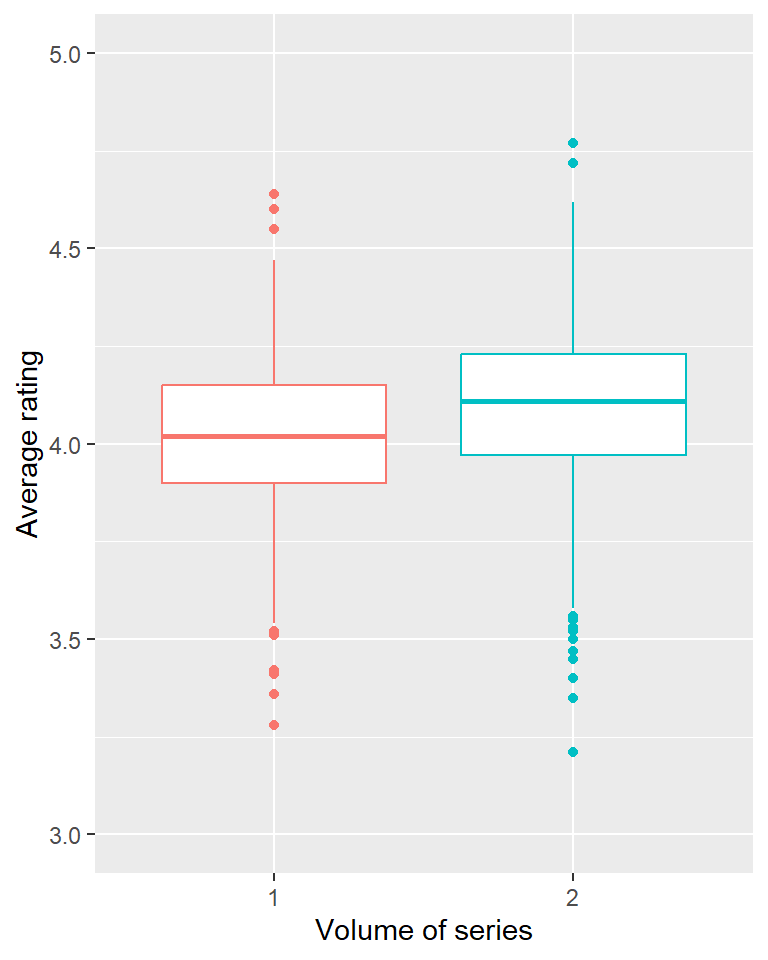

```r
books <- books %>%
  mutate(series = str_extract(title, "\\(.*\\)"),
         series_number = as.numeric(str_sub(str_extract(series, ', #[0-9]+\\)$'),4,-2)),
         series_name = str_sub(str_extract(series, '\\(.*,'),2,-2))

books %>%
  filter(!is.na(series_name) & !is.na(series_number) & series_number %in% c(1,2)) %>%
  group_by(series_name, series_number) %>%
  summarise(m = mean(average_rating)) %>%
  ungroup() %>%
  group_by(series_name) %>%
  mutate(n = n()) %>%
  filter(n == 2) %>%
  ggplot(aes(factor(series_number), m, color = factor(series_number))) +
  geom_boxplot() + coord_cartesian(ylim = c(3,5)) + guides(color = FALSE) + labs(x = "Volume of series", y = "Average rating")
```

## Part II: Filtros colaborativos

En este filtro colaborativo basado en usuarios consideramos los siguiente puntos:

1. Identificar otros usuarios con gustos similares al usuario en cuestion en términos de los libros y calificaciones que tienen en comun.
2. Si encontramos estos usuarios similares entonces tomamos el promedio de las calificaciones de los libros que el usuario en cuestion no ha leido aún.
3. Recomendar aquellos libros con la calificacion promedio más alto.

Estos tres pasos los convertirmos en un algoritmo. Pero antes de iniciar tenemos que construir los datos. A continuación crearemos una matriz donde las filas corresponden a los usuarios y cada columna corresponde a los libros. Una matriz de ejemplo para 3 usuarios y 5 libros se muestra a continuación. Como podremos observar no todos los usuarios han calificado todos los libros.

```
##        book_id
## user_id  1  2  3  4  5
##       1 NA NA  4 NA NA
##       2  2  1 NA NA NA
##       3 NA NA  3 NA  3
```

Para convertir nuestos datos en esta matriz lo haremos de la siguiente manera:

```r
dimension_names <- list(user_id = sort(unique(ratings$user_id)),
                        book_id = sort(unique(ratings$book_id)))

ratingmat <- spread(select(ratings,
                           book_id,
                           user_id,
                           rating),
                    book_id,
                    rating) %>% select(-user_id)

ratingmat <- as.matrix(ratingmat)
dimnames(ratingmat) <- dimension_names
ratingmat[1:5, 1:5]
```

```
##        book_id
## user_id  1  2  3  5  6
##      7  NA NA NA NA NA
##      10 NA NA NA NA NA
##      23 NA NA NA NA NA
##      27 NA NA NA NA NA
##      35 NA NA NA NA NA
```

```r
dim(ratingmat)
```

```
## [1] 10045   812
```

Podemos ver que nuestra matriz de calificaciones tiene 10,045 filas x 812 columnas. Ahora tenemos listos nuestros datos.

Ahora continuaremos con los tres primeros pasos.

### Paso 1: Encontrar usuarios similares

En este paso seleccionaremos usuarios que tengan en común los mismos libros. Seleccionaremos un usuario de ejemplo “David” (user_id: 17329). 1) Seleccionamos usuarios que han calificado los mismos libros que David también ha calificado. 2) Veremos que en total tenemos 189 usuarios que tienen al menos un par de libros en común.

```r
current_user <- "17329"
rated_items <- which(!is.na((as.data.frame(ratingmat[current_user, ]))))
selected_users <- names(which(apply(!is.na(ratingmat[ ,rated_items]), 1, sum) >= 2))
head(selected_users, 40)
```

```
##  [1] "314"   "725"   "1064"  "1323"  "1794"  "2077"  "2271"  "3114"  "3757"
## [10] "3982"  "4289"  "4641"  "4859"  "5100"  "5109"  "5161"  "5303"  "6323"
## [19] "6390"  "7585"  "7857"  "8146"  "8278"  "8337"  "8371"  "8463"  "8579"
## [28] "8587"  "8632"  "8770"  "8899"  "9123"  "9557"  "9698"  "9722"  "10087"
## [37] "10110" "10140" "10288" "10502"
```

```r
length(selected_users)
```

```
## [1] 189
```

Para estos usuarios podemos calcular la similitud de sus calificaciones con las de “David”. Existen varias opciones para calcular la similitud. Típicamente se utiliza el coseno de similitud o la correlación de Pearson.

```r
user1 <- data.frame(item=colnames(ratingmat),
                    rating=ratingmat[current_user,]) %>% filter(!is.na(rating))

user2 <- data.frame(item=colnames(ratingmat),
                    rating=ratingmat["26990",]) %>% filter(!is.na(rating))

tmp<-merge(user1, user2, by="item")
tmp
```

| item | rating.x | rating.y |
| --- | --- | --- |
| 1032 | 5 | 5 |
| 2696 | 3 | 2 |
| 3304 | 3 | 3 |
| 5107 | 3 | 5 |
| 6334 | 3 | 4 |
| 976 | 5 | 5 |

```r
cor_u1 <- cor(tmp$rating.x, tmp$rating.y, use="pairwise.complete.obs")
print(paste("1339", cor_u1, sep=':'))
```

```
## [1] "1339:0.612372435695794"
```

```r
user2 <- data.frame(item = colnames(ratingmat), rating = ratingmat["26990", ]) %>% filter(!is.na(rating))
tmp <- merge(user1, user2, by="item")
tmp
```

| item | rating.x | rating.y |
| --- | --- | --- |
| 1032 | 5 | 5 |
| 2696 | 3 | 2 |
| 3304 | 3 | 3 |
| 5107 | 3 | 5 |
| 6334 | 3 | 4 |
| 976 | 5 | 5 |

```r
cor_2 <- cor(tmp$rating.x, tmp$rating.y, use="pairwise.complete.obs")

print(paste("26990", cor_2, sep=':'))
```

```
## [1] "26990:0.612372435695794"
```

Para reducir la influencia de diferencias interindividuales en las calificaiones medias podemos normalizar las calificaciones de los usuarios substrayendo la media del usuario de todas las calificaiones individuales. Por ejemplo si un usuario calificó 5 libros con 1, 2, 3, 4, 5 sus calificaciones se convertirán en -2, -1, 0, 1, 2. (media es: 3).

```r
rmat <- ratingmat[selected_users, ]
user_mean_ratings <- rowMeans(rmat,na.rm=T)
rmat <- rmat - user_mean_ratings
```

Ahora calculamremos la similitud de todos los usuarios contra David y los ordenaremos de acuerdo a la similitud más alta.

```r
similarities <- cor(t(rmat[rownames(rmat) != current_user, ]),
                    rmat[current_user, ],
                    use='pairwise.complete.obs')

sim <- as.vector(similarities)
names(sim) <- rownames(similarities)
res <- sort(sim, decreasing = TRUE)
head(res, 40)
```

```
##   725  2271  3757  5109  5303  7857  8278  9722 10087 10704 12014 13353 13629
##     1     1     1     1     1     1     1     1     1     1     1     1     1
## 15194 17493 17832 18199 18798 18957 20076 20737 21599 22243 22744 24383 28443
##     1     1     1     1     1     1     1     1     1     1     1     1     1
## 28481 29031 29572 30358 30681 31305 33119 33147 33207 33556 34531 34808 35259
##     1     1     1     1     1     1     1     1     1     1     1     1     1
## 37035
##     1
```

**Visualizaremos las similitud entre usuarios.**

Las similitudes entre usuarios pueden visualizarse usuando el paquete qgraph. El ancho de las aristas corresponden a la similitud entre usuarios (azul para correlación positiva y rojo para correlación negativa).

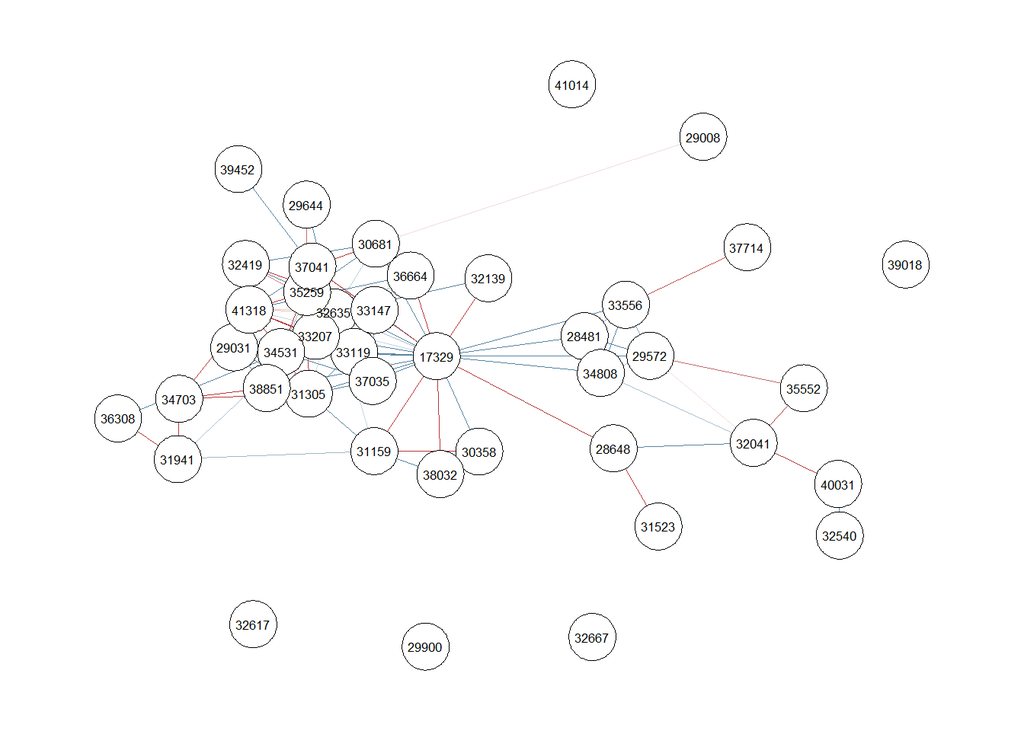

```r
sim_mat <- cor(t(rmat), use = 'pairwise.complete.obs')
random_users <- selected_users[120:160]
qgraph(sim_mat[c(current_user, random_users),
               c(current_user, random_users)],
       layout="spring",
       vsize=5,
       theme="TeamFortress",
       labels=c(current_user, random_users))
```

### Paso 2: Obtener predicciones de libros

Para obtener recomendaciones para nuestro usuario debemos tomar los usuarios más similares (por ejemplo 4) y promediar sus calificaciones para aquellos los libros que David aún no ha calificado. Para obtener promedios más confiables podemos incluir únicamente productos que han sido calificados por otros usuarios similares.

```r
similar_users <- names(res[1:4])

similar_users_ratings <- data.frame(item = rep(colnames(rmat),
                                               length(similar_users)),
                                    rating = c(t(as.data.frame(rmat[similar_users,])))) %>% filter(!is.na(rating))

current_user_ratings <- data.frame(item = colnames(rmat),
                                   rating = rmat[current_user,]) %>% filter(!is.na(rating))

predictions <- similar_users_ratings %>%
  filter(!(item %in% current_user_ratings$item)) %>%
  group_by(item) %>%
  summarize(mean_rating = mean(rating))

predictions %>%
    datatable(class = "nowrap hover row-border", options = list(dom = 't', scrollX = TRUE, autoWidth = TRUE))
```

|  | item | mean_rating |
| --- | --- | --- |
| 1 | 1052 | -1 |
| 2 | 106 | -0.153846153846154 |
| 3 | 112 | 0 |
| 4 | 1427 | -0.153846153846154 |
| 5 | 1635 | 0.428571428571429 |
| 6 | 1845 | 0.846153846153846 |
| 7 | 1897 | 1 |
| 8 | 1898 | 1 |
| 9 | 1911 | 1 |
| 10 | 2049 | -0.571428571428571 |

[output cut: 20 more lines]

```r
predictions %>%
  arrange(-mean_rating) %>%
  top_n(10, wt = mean_rating) %>%
  mutate(book_id = as.numeric(as.character(item))) %>%
  left_join(select(books, authors, title, book_id), by = "book_id") %>%
  select(-item) %>%
  datatable(class = "nowrap hover row-border", options = list(dom = 't',scrollX = TRUE, autoWidth = TRUE))
```

|  | mean_rating | book_id | authors | title |
| --- | --- | --- | --- | --- |
| 1 | 1 | 1897 | Jon Krakauer | Eiger Dreams: Ventures Among Men and Mountains |
| 2 | 1 | 1898 | Jon Krakauer | Into Thin Air: A Personal Account of the Mount Everest Disaster |
| 3 | 1 | 1911 | Thomas L. Friedman | The World Is Flat: A Brief History of the Twenty-first Century |
| 4 | 1 | 3028 | Henry Hazlitt | Economics in One Lesson: The Shortest &amp; Surest Way to Understand Basic Economics |
| 5 | 1 | 446 | Paul Auster | The Brooklyn Follies |
| 6 | 1 | 5182 | Mary McGarry Morris | Songs in Ordinary Time |
| 7 | 1 | 665 | Ayn Rand, Nathaniel Branden | The Virtue of Selfishness: A New Concept of Egoism |
| 8 | 1 | 998 | Thomas J. Stanley, William D. Danko | The Millionaire Next Door: The Surprising Secrets of Americas Wealthy |
| 9 | 0.923076923076923 | 295 | Robert Louis Stevenson | Treasure Island |
| 10 | 0.846153846153846 | 1845 | Jon Krakauer | Into the Wild |

[output cut: 1 more lines]

Este es el principio básico del filtro colaborativo basado en usuarios. Ahora podemos evaluar y comparar algunos algoritmos de recomendación.

### Usando recommenderlab

Recommenderlab es un paquete de R que provee la infraestructura para evaluar y comprara multiples algoritmos basados en filtros colaborativos.

Muchos algoritmos han sido implementados en este paquete. Podemos utilizarlos para ahorrar el esfuerzo al codificar y evaluar.

Hay una aspecto importante al considerar la representación de la matriz. Como podimos ver anteriormente, la mayoría de los valores en la matriz de calificaiones no se encuentran, ya que los usuarios califican pocos libros. Esto nos permitirá representar la matriz en un formato disperso para ahorrar memoria.

```r
ratingmat0 <- ratingmat
ratingmat0[is.na(ratingmat0)] <- 0
sparse_ratings <- as(ratingmat0, "sparseMatrix")
rm(ratingmat0)
gc()
```

Recommenderlab utiliza una variante especial de las matrices dispersas, así que primero convertimos la matriz en esta clase.

```r
real_ratings <- new("realRatingMatrix", data = sparse_ratings)
real_ratings
```

```
## 10045 x 812 rating matrix of class 'realRatingMatrix' with 54558 ratings.
```

Ejecutar un algoritmo en Recommederlab es realmente fácil. Todo lo que tenemos que hacer es llamar a `Recommender()` y pasarle los datos, seleccionar el método (“UBCF” - user-based collaborative filtering) y pasar algunos parámetros, por ejemplo el método para calcular la similitud y el número de usuarios similares para usar en la predicción).

```r
model <- Recommender(real_ratings, method = "UBCF", param = list(method = "pearson", nn = 4))
```

Crear las predicciones también es muy intuitivo. Solamente hay que llamar a `predict()` y pasar el modelo, las calificaciones de los usuarios que quieres predicir. y un parámetro que nos diga la función que quieres utilizar para obtener las predicciones de las calificaciones.

```r
#Making predictions
prediction <- predict(model, real_ratings[current_user, ], type = "ratings")
```

Veremos las mejores predicciones para David:

```r
as(prediction, 'data.frame') %>%
  arrange(-rating) %>% .[1:5,] %>%
  mutate(book_id = as.numeric(as.character(item))) %>%
  left_join(select(books, authors, title, book_id), by = "book_id") %>%
  select(-item) %>%
  datatable(class = "nowrap hover row-border", escape = FALSE, options = list(dom = 't',scrollX = TRUE, autoWidth = TRUE))
```

|  | user | rating | book_id | authors | title |
| --- | --- | --- | --- | --- | --- |
| 1 | 17329 | 4.75 | 446 | Paul Auster | The Brooklyn Follies |
| 2 | 17329 | 4.75 | 665 | Ayn Rand, Nathaniel Branden | The Virtue of Selfishness: A New Concept of Egoism |
| 3 | 17329 | 4.75 | 998 | Thomas J. Stanley, William D. Danko | The Millionaire Next Door: The Surprising Secrets of Americas Wealthy |
| 4 | 17329 | 4.75 | 1897 | Jon Krakauer | Eiger Dreams: Ventures Among Men and Mountains |
| 5 | 17329 | 4.75 | 1898 | Jon Krakauer | Into Thin Air: A Personal Account of the Mount Everest Disaster |

**Algunas ideas para mejorar el modelo.**

El procedimiento mostrado es muy simple. Podemos realizar algunas mejores al algoritmo: 1. Podemos medir la calificaciones por similitud. Esto significa que entre mayor la similitud de un usuario con el usuario en cuestion entonces sus calificaiones reciben un mayor peso en el cálculo de las predicciones.

2. El cálculo de la similitud puede llevar pesos de acuerdo a las calificaiones que los usuarios han dado a libros que tienen en común. Entre más calificaiones en común mayor el puntaje de similitud.

**Evaluando las predicciones.**

Otra ventaja de `Recommenderlab` es que ofrece la posibilidad de evaluar y comparar fácilmente los algoritmos. Para hacer esto, primero tenemos que crear un esquema de evaluación. Por ejemplo utiliar una validación cruzada de 10. El primer parámetro determina cuantas calificaiones son dadas para crear las predicciones y cuantas predicciones por usuario se utilizaran para evaluarlas. En el caso de -1 indica el numero de items a remover y su desempeño se evalua con 1 para cada usuario.

```r
scheme <- evaluationScheme(real_ratings[1:500,], method = "cross-validation", k = 10, given = -1, goodRating = 5)
```

Como segundo paso, enlistaremos todos los algoritmos que queremos comparar. Los algoritmos que evaluaremos son el IBCF (Item Based Colaborative Filter), el SVD (Singular Value Decomposition), POPULAR, el cual se basa en la popularidad del objeto para realizar una recomendación y un algoritmo aleatorio (RANDOM).

```r
algorithms <- list("random" = list(name = "RANDOM", param = NULL),
                   "IBCF" = list(name = "IBCF", param = list(method='Pearson', k=10)),
                   "SVD" = list(name = "SVD", param = list(k=10)),
                   "POPULAR" = list(name = "POPULAR")
                   )
# evaluate the alogrithms with the given scheme
results <- evaluate(scheme, algorithms, type = "ratings")
```

```
## RANDOM run fold/sample [model time/prediction time]
##   1  [0sec/0sec]
##   2  [0sec/0sec]
##   3  [0.02sec/0sec]
##   4  [0sec/0sec]
##   5  [0sec/0sec]
##   6  [0sec/0.01sec]
##   7  [0sec/0sec]
##   8  [0sec/0sec]
##   9  [0sec/0.02sec]
##   10  [0sec/0.02sec]
## IBCF run fold/sample [model time/prediction time]
##   1  [0.39sec/0.01sec]
##   2  [0.3sec/0sec]
##   3  [0.21sec/0sec]
```

[output cut: 29 more lines]

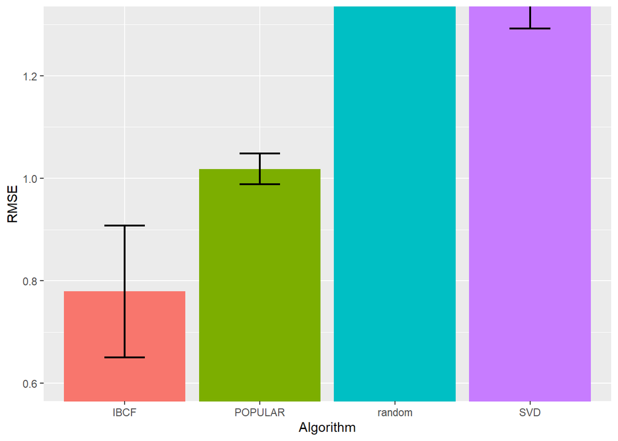

```r
# Test with TopN

# results <- evaluate(scheme, algorithms, type = "topNList")

# restructure results output
tmp <- lapply(results, function(x) slot(x, "results"))
res <- tmp %>%
  lapply(function(x) unlist(lapply(x, function(x) unlist(x@cm[ ,"RMSE"])))) %>%
  as.data.frame() %>%
  gather(key = "Algorithm", value = "RMSE")

res %>%
  ggplot(aes(Algorithm, RMSE, fill = Algorithm)) +
  geom_bar(stat = "summary") + geom_errorbar(stat = "summary", width = 0.3, size = 0.8) +
  coord_cartesian(ylim = c(0.6, 1.3)) + guides(fill = FALSE)
```

Podemos ver que de todos los algoritmos, el Item Based Collaborative Filter se desempeñan mejor.

### Algoritmos disponibles

También es posbile comparar el desempeño contra diferentes algoritmos. Los siguientes son los disponibles:ble:

```r
recommenderRegistry$get_entry_names()
```

```
##  [1] "HYBRID_realRatingMatrix"         "HYBRID_binaryRatingMatrix"
##  [3] "ALS_realRatingMatrix"            "ALS_implicit_realRatingMatrix"
##  [5] "ALS_implicit_binaryRatingMatrix" "AR_binaryRatingMatrix"
##  [7] "IBCF_binaryRatingMatrix"         "IBCF_realRatingMatrix"
##  [9] "LIBMF_realRatingMatrix"          "POPULAR_binaryRatingMatrix"
## [11] "POPULAR_realRatingMatrix"        "RANDOM_realRatingMatrix"
## [13] "RANDOM_binaryRatingMatrix"       "RERECOMMEND_realRatingMatrix"
## [15] "RERECOMMEND_binaryRatingMatrix"  "SVD_realRatingMatrix"
## [17] "SVDF_realRatingMatrix"           "UBCF_binaryRatingMatrix"
## [19] "UBCF_realRatingMatrix"
```

Puedes obtener más información acerca de estos algitmos con el siguiente comando.

```r
recommenderRegistry$get_entries(dataType = "realRatingMatrix")
```

### Resumen parte II

En los filtros colaborativos la idea principal es utilizar las califcaiones de usuarios similares para crear recomendaciones. El algoritmo básico es fácil de implementar a mano. Pero existen paquetes como Recomenderlab que ayudan mucho a simplificar el trabajo.

| Autor | Josue Huaman |
| --- | --- |
| Archivado en | [Machine Learning](https://josuemzx.github.io/blog/tags/machine-learning/index.html) |